# Project 1

Vivi Feathers, Li-Chia Chang

# Part 1 - Data Processing

## First Step

EDU01a data processing.

Read in the EDU01a data as sheet1 using the code below.

```r
library(readr)
sheet1 <- read_csv("https://www4.stat.ncsu.edu/~online/datasets/EDU01a.csv")
sheet1
```

```
## # A tibble: 3,198 × 42
##    Area_name     STCOU EDU010187F EDU010187D EDU010187N1 EDU010187N2 EDU010188F
##    <chr>         <chr>      <dbl>      <dbl> <chr>       <chr>            <dbl>
##  1 UNITED STATES 00000          0   40024299 0000        0000                 0
##  2 ALABAMA       01000          0     733735 0000        0000                 0
##  3 Autauga, AL   01001          0       6829 0000        0000                 0
##  4 Baldwin, AL   01003          0      16417 0000        0000                 0
##  5 Barbour, AL   01005          0       5071 0000        0000                 0
##  6 Bibb, AL      01007          0       3557 0000        0000                 0
##  7 Blount, AL    01009          0       7319 0000        0000                 0
##  8 Bullock, AL   01011          0       2014 0000        0000                 0
##  9 Butler, AL    01013          0       4640 0000        0000                 0
## 10 Calhoun, AL   01015          0      20939 0000        0000                 0
## # ℹ 3,188 more rows
## # ℹ 35 more variables: EDU010188D <dbl>, EDU010188N1 <chr>, EDU010188N2 <chr>,
## #   EDU010189F <dbl>, EDU010189D <dbl>, EDU010189N1 <chr>, EDU010189N2 <chr>,
## #   EDU010190F <dbl>, EDU010190D <dbl>, EDU010190N1 <chr>, EDU010190N2 <chr>,
## #   EDU010191F <dbl>, EDU010191D <dbl>, EDU010191N1 <chr>, EDU010191N2 <chr>,
## #   EDU010192F <dbl>, EDU010192D <dbl>, EDU010192N1 <chr>, EDU010192N2 <chr>,
## #   EDU010193F <dbl>, EDU010193D <dbl>, EDU010193N1 <chr>, EDU010193N2 <chr>, …
```

### 1. Select columns

Select “Area_name” column and rename as “area_name”; select “STCOU” column and any column that ends in “D” and save it into `sheet1_select`.

```r
library(tidyverse)
sheet1_select <- sheet1 %>%
                   rename("area_name" = Area_name) %>% ## rename Area_name to area_name
                   select(area_name, STCOU, ends_with("D")) ## select columns as required
sheet1_select
```

```
## # A tibble: 3,198 × 12
##    area_name     STCOU EDU010187D EDU010188D EDU010189D EDU010190D EDU010191D
##    <chr>         <chr>      <dbl>      <dbl>      <dbl>      <dbl>      <dbl>
##  1 UNITED STATES 00000   40024299   39967624   40317775   40737600   41385442
##  2 ALABAMA       01000     733735     728234     730048     728252     725541
##  3 Autauga, AL   01001       6829       6900       6920       6847       7008
##  4 Baldwin, AL   01003      16417      16465      16799      17054      17479
##  5 Barbour, AL   01005       5071       5098       5068       5156       5173
##  6 Bibb, AL      01007       3557       3508       3571       3621       3652
##  7 Blount, AL    01009       7319       7223       7205       7209       7155
##  8 Bullock, AL   01011       2014       1980       1985       1983       1985
##  9 Butler, AL    01013       4640       4582       4610       4591       4544
## 10 Calhoun, AL   01015      20939      20923      20907      20849      20768
## # ℹ 3,188 more rows
## # ℹ 5 more variables: EDU010192D <dbl>, EDU010193D <dbl>, EDU010194D <dbl>,
## #   EDU010195D <dbl>, EDU010196D <dbl>
```

### 2. Convert `sheet1_select` into long format

Convert `sheet1_select` into long format where each row has one enrollment value for “area_name”, save it into `sheet1_convert`.

```r
sheet1_convert <- sheet1_select %>%
## convert to long format and create 2 new columns
                    pivot_longer(cols = 3:12, names_to = "survey_id", values_to = "enrollment")
sheet1_convert
```

```
## # A tibble: 31,980 × 4
##    area_name     STCOU survey_id  enrollment
##    <chr>         <chr> <chr>           <dbl>
##  1 UNITED STATES 00000 EDU010187D   40024299
##  2 UNITED STATES 00000 EDU010188D   39967624
##  3 UNITED STATES 00000 EDU010189D   40317775
##  4 UNITED STATES 00000 EDU010190D   40737600
##  5 UNITED STATES 00000 EDU010191D   41385442
##  6 UNITED STATES 00000 EDU010192D   42088151
##  7 UNITED STATES 00000 EDU010193D   42724710
##  8 UNITED STATES 00000 EDU010194D   43369917
##  9 UNITED STATES 00000 EDU010195D   43993459
## 10 UNITED STATES 00000 EDU010196D   44715737
## # ℹ 31,970 more rows
```

### 3. Create 2 new columns

Split the “survey_id” column into 2 new columns: get the 8th and 9th sub string from survey_id, convert to numeric, concatenate with “19” if it is bigger than 10, otherwise concatenate with “20”, to complete the year format, convert character to numeric and save in “year”. Then get the first 7 sub string from “survey_id”, put them into new columns “measurement”. Save the output into `sheet1_newcol`.

```r
sheet1_newcol <- sheet1_convert %>%
## get the 8th and 9th sub string from survey_id, convert to numeric, concatenate with "19" if it is bigger than 10, otherwise concatenate with "20", to complete the year format, convert character to numeric and save in `year`, then get the first 7 sub string from survey_id, put them into `new columns`measurement`
                   mutate(year = as.numeric(paste0(if_else(as.numeric(substr(sheet1_convert$survey_id, 8, 9)) > 10, "19", "20"), substr(sheet1_convert$survey_id, 8, 9))), measurement = substr(sheet1_convert$survey_id, 1, 7))
sheet1_newcol
```

```
## # A tibble: 31,980 × 6
##    area_name     STCOU survey_id  enrollment  year measurement
##    <chr>         <chr> <chr>           <dbl> <dbl> <chr>
##  1 UNITED STATES 00000 EDU010187D   40024299  1987 EDU0101
##  2 UNITED STATES 00000 EDU010188D   39967624  1988 EDU0101
##  3 UNITED STATES 00000 EDU010189D   40317775  1989 EDU0101
##  4 UNITED STATES 00000 EDU010190D   40737600  1990 EDU0101
##  5 UNITED STATES 00000 EDU010191D   41385442  1991 EDU0101
##  6 UNITED STATES 00000 EDU010192D   42088151  1992 EDU0101
##  7 UNITED STATES 00000 EDU010193D   42724710  1993 EDU0101
##  8 UNITED STATES 00000 EDU010194D   43369917  1994 EDU0101
##  9 UNITED STATES 00000 EDU010195D   43993459  1995 EDU0101
## 10 UNITED STATES 00000 EDU010196D   44715737  1996 EDU0101
## # ℹ 31,970 more rows
```

### 4. Create two data sets.

Subset `sheet1_newcol` into 2 data sets: one has only county level data, it has “area_name” values following the “County Name, DD” pattern, use a subset function with a grepl function to find those records, save them in `sheet1_county`and add a class to the tibble called “county”.The other data set contains only non-county data, find those records by comparing the `area_name` values of `sheet1_newcol` with the `area_name` values of `sheet1_county`, the ones that are not in `sheet1_county` get output, add a class to the tibble called “state”, save it in `sheet1_noncounty`.

```r
sheet1_county <- sheet1_newcol %>%
## find records that have area_name following the "County Name, DD" pattern
                   subset(grepl(pattern = ", \\w\\w", sheet1_newcol$area_name))
## add class called "county"
                   class(sheet1_county) <- c("county", class(sheet1_county))
sheet1_county
```

```
## # A tibble: 31,450 × 6
##    area_name   STCOU survey_id  enrollment  year measurement
##    <chr>       <chr> <chr>           <dbl> <dbl> <chr>
##  1 Autauga, AL 01001 EDU010187D       6829  1987 EDU0101
##  2 Autauga, AL 01001 EDU010188D       6900  1988 EDU0101
##  3 Autauga, AL 01001 EDU010189D       6920  1989 EDU0101
##  4 Autauga, AL 01001 EDU010190D       6847  1990 EDU0101
##  5 Autauga, AL 01001 EDU010191D       7008  1991 EDU0101
##  6 Autauga, AL 01001 EDU010192D       7137  1992 EDU0101
##  7 Autauga, AL 01001 EDU010193D       7152  1993 EDU0101
##  8 Autauga, AL 01001 EDU010194D       7381  1994 EDU0101
##  9 Autauga, AL 01001 EDU010195D       7568  1995 EDU0101
## 10 Autauga, AL 01001 EDU010196D       7834  1996 EDU0101
## # ℹ 31,440 more rows
```

```r
## find records that do not have area_name value in sheet1_county area_name values
sheet1_noncounty <- sheet1_newcol[! sheet1_newcol$area_name %in% sheet1_county$area_name, ]
## add class called "state"
                   class(sheet1_noncounty) <- c("state", class(sheet1_noncounty))
sheet1_noncounty
```

```
## # A tibble: 530 × 6
##    area_name     STCOU survey_id  enrollment  year measurement
##    <chr>         <chr> <chr>           <dbl> <dbl> <chr>
##  1 UNITED STATES 00000 EDU010187D   40024299  1987 EDU0101
##  2 UNITED STATES 00000 EDU010188D   39967624  1988 EDU0101
##  3 UNITED STATES 00000 EDU010189D   40317775  1989 EDU0101
##  4 UNITED STATES 00000 EDU010190D   40737600  1990 EDU0101
##  5 UNITED STATES 00000 EDU010191D   41385442  1991 EDU0101
##  6 UNITED STATES 00000 EDU010192D   42088151  1992 EDU0101
##  7 UNITED STATES 00000 EDU010193D   42724710  1993 EDU0101
##  8 UNITED STATES 00000 EDU010194D   43369917  1994 EDU0101
##  9 UNITED STATES 00000 EDU010195D   43993459  1995 EDU0101
## 10 UNITED STATES 00000 EDU010196D   44715737  1996 EDU0101
## # ℹ 520 more rows
```

### 5. Create state variable for the county level tibble

Obtain the state name by using sub function and get the sub string after “,” from column “area_name”, output them into a new column called “state”.

```r
sheet1_county <- sheet1_county %>%
## store the state info into a new column by using sub function and get the sub string after "," from column area_name
                   mutate(state = sub(".+, (.+)", "\\1", sheet1_county$area_name))
sheet1_county
```

```
## # A tibble: 31,450 × 7
##    area_name   STCOU survey_id  enrollment  year measurement state
##    <chr>       <chr> <chr>           <dbl> <dbl> <chr>       <chr>
##  1 Autauga, AL 01001 EDU010187D       6829  1987 EDU0101     AL
##  2 Autauga, AL 01001 EDU010188D       6900  1988 EDU0101     AL
##  3 Autauga, AL 01001 EDU010189D       6920  1989 EDU0101     AL
##  4 Autauga, AL 01001 EDU010190D       6847  1990 EDU0101     AL
##  5 Autauga, AL 01001 EDU010191D       7008  1991 EDU0101     AL
##  6 Autauga, AL 01001 EDU010192D       7137  1992 EDU0101     AL
##  7 Autauga, AL 01001 EDU010193D       7152  1993 EDU0101     AL
##  8 Autauga, AL 01001 EDU010194D       7381  1994 EDU0101     AL
##  9 Autauga, AL 01001 EDU010195D       7568  1995 EDU0101     AL
## 10 Autauga, AL 01001 EDU010196D       7834  1996 EDU0101     AL
## # ℹ 31,440 more rows
```

### 6. Create a division variable for the non-county level tibble

According to [WIKIPEDIA](https://en.wikipedia.org/wiki/List_of_regions_of_the_United_States), find the division name for each state using series of `if_else` functions: if a state name is with`%in%` a division’s state name string, its “division” value will be the corresponding division name, otherwise process to the next division state name string.

```r
## check the distinct value in area_name
#unique(sheet1_noncounty$area_name)

sheet1_noncounty <- sheet1_noncounty %>%
                      mutate(division = if_else(area_name == "UNITED STATES", "ERROR",
                                                if_else(area_name %in% c("CONNECTICUT", "MAINE", "MASSACHUSETTS", "NEW HAMPSHIRE", "RHODE ISLAND", "VERMONT"), "NEW ENGLAND",
                                                        if_else(area_name %in% c("ILLINOIS", "INDIANA", "MICHIGAN", "OHIO", "WISCONSIN"), "EAST NORTH CENTRAL",
                                                                if_else(area_name %in% c("IOWA", "KANSAS", "MINNESOTA", "MISSOURI", "NEBRASKA", "NORTH DAKOTA", "SOUTH DAKOTA"), "WEST NORTH CENTRAL",
                                                                        if_else(area_name %in% c("NEW JERSEY", "NEW YORK", "PENNSYLVANIA"), "MIDDLE ATLANTIC",
                                                                                if_else(area_name %in% c("DELAWARE", "FLORIDA", "GEORGIA", "MARYLAND", "NORTH CAROLINA", "SOUTH CAROLINA", "VIRGINIA", "DISTRICT OF COLUMBIA", "District of Columbia", "WEST VIRGINIA"), "SOUTH ATLANTIC",
                                                                                        if_else(area_name %in% c("ALABAMA", "KENTUCKY", "MISSISSIPPI", "TENNESSEE"), "EAST SOUTH CENTRAL",
                                                                                                if_else(area_name %in% c("ARKANSAS", "LOUISIANA", "OKLAHOMA", "TEXAS"), "WEST SOUTH CENTRAL",
                                                                                                        if_else(area_name %in% c("ARIZONA", "COLORADO", "IDAHO", "MONTANA", "NEVADA", "NEW MEXICO", "UTAH", "WYOMING"), "MOUNTAIN",
                                                                                                                if_else(area_name %in% c("ALASKA", "CALIFORNIA", "HAWAII", "OREGON", "WASHINGTON"), "PACIFIC", "")))))))))))
sheet1_noncounty
```

```
## # A tibble: 530 × 7
##    area_name     STCOU survey_id  enrollment  year measurement division
##    <chr>         <chr> <chr>           <dbl> <dbl> <chr>       <chr>
##  1 UNITED STATES 00000 EDU010187D   40024299  1987 EDU0101     ERROR
##  2 UNITED STATES 00000 EDU010188D   39967624  1988 EDU0101     ERROR
##  3 UNITED STATES 00000 EDU010189D   40317775  1989 EDU0101     ERROR
##  4 UNITED STATES 00000 EDU010190D   40737600  1990 EDU0101     ERROR
##  5 UNITED STATES 00000 EDU010191D   41385442  1991 EDU0101     ERROR
##  6 UNITED STATES 00000 EDU010192D   42088151  1992 EDU0101     ERROR
##  7 UNITED STATES 00000 EDU010193D   42724710  1993 EDU0101     ERROR
##  8 UNITED STATES 00000 EDU010194D   43369917  1994 EDU0101     ERROR
##  9 UNITED STATES 00000 EDU010195D   43993459  1995 EDU0101     ERROR
## 10 UNITED STATES 00000 EDU010196D   44715737  1996 EDU0101     ERROR
## # ℹ 520 more rows
```

## Requirements

Now we want to repeat the above process for the 2nd component of the data set. Instead of than copying and pasting from previous code, we want to write functions that do above steps then create a wrapped function to do everything in one function call.

### 1. Write one function that does steps 1 & 2 above

```r
##`df1` is for data frame name and `col_name` is for defining the column name which stores the enrollment values`
step_one_two <- function(df1, var_name) {
                                   df1 %>%
                                     rename("area_name" = Area_name) %>% ## rename Area_name to area_name
                                     select(area_name, STCOU, ends_with("D")) %>% ## select columns as required
                                     pivot_longer(cols = 3:12, names_to = "survey_id", values_to = var_name) ## convert to long format and create 2 new columns
}
```

### 2. Write one function that does steps 3 above

Write one function called `step_three` that takes in the output from step 1 & 2, and creates a new tibble in step 3. In the `step_three` function, `df2` is for inputting data frame name.

```r
##`df2` is for data frame name
step_three <- function(df2) {
                                  df2 %>%
## get the 8th and 9th sub string from survey_id, convert to numeric, concatenate with "19" if it is bigger than 10, otherwise concatenate with "20", to complete the year format, convert character to numeric and save in `year`, then get the first 7 sub string from survey_id, put them into `new columns`measurement`
                                    mutate(year = as.numeric(paste0(if_else(as.numeric(substr(df2$survey_id, 8, 9)) > 10, "19", "20"), substr(df2$survey_id, 8, 9))), measuement = substr(df2$survey_id, 1, 7))
}
```

### 3. Write one function that does steps 5 above

Write one function called `step_five` that takes in the output from step 4 and creates a new tibble in step 5. In the`step_five` function, `df4` is for inputting data frame name.

```r
##`df4` is for data frame name
step_five <- function(df4) {
              sheet1_county_final <<- df4 %>%
## store the state info into a new column by using sub function and get the sub string after "," from column area_name
                                   mutate(state = sub(".+, (.+)", "\\1", df4$area_name))

}
```

### 4. Write one function that does steps 6 above

Write one function called `step_six` that takes in the output from step 4 and creates a new tibble in step 6. In `step_six` function, `df5` is for inputting data frame name.

```r
##`df5` is for data frame name
step_six <- function(df5) {
              sheet1_noncounty_final <<- df5 %>%
                                     mutate(division = if_else(area_name == "UNITED STATES", "ERROR",
                                                        if_else(area_name %in% c("CONNECTICUT", "MAINE", "MASSACHUSETTS", "NEW HAMPSHIRE", "RHODE ISLAND", "VERMONT"), "NEW ENGLAND",
                                                         if_else(area_name %in% c("ILLINOIS", "INDIANA", "MICHIGAN", "OHIO", "WISCONSIN"), "EAST NORTH CENTRAL",
                                                          if_else(area_name %in% c("IOWA", "KANSAS", "MINNESOTA", "MISSOURI", "NEBRASKA", "NORTH DAKOTA", "SOUTH DAKOTA"), "WEST NORTH CENTRAL",
                                                           if_else(area_name %in% c("NEW JERSEY", "NEW YORK", "PENNSYLVANIA"), "MIDDLE ATLANTIC",
                                                            if_else(area_name %in% c("DELAWARE", "FLORIDA", "GEORGIA", "MARYLAND", "NORTH CAROLINA", "SOUTH CAROLINA", "VIRGINIA", "DISTRICT OF COLUMBIA", "District of Columbia", "WEST VIRGINIA"), "SOUTH ATLANTIC",
                                                             if_else(area_name %in% c("ALABAMA", "KENTUCKY", "MISSISSIPPI", "TENNESSEE"), "EAST SOUTH CENTRAL",
                                                              if_else(area_name %in% c("ARKANSAS", "LOUISIANA", "OKLAHOMA", "TEXAS"), "WEST SOUTH CENTRAL",
                                                               if_else(area_name %in% c("ARIZONA", "COLORADO", "IDAHO", "MONTANA", "NEVADA", "NEW MEXICO", "UTAH", "WYOMING"), "MOUNTAIN",
                                                                if_else(area_name %in% c("ALASKA", "CALIFORNIA", "HAWAII", "OREGON", "WASHINGTON"), "PACIFIC", "")))))))))))
              #return (sheet1_noncounty_final)
}
#step_six (sheet1_noncounty)
```

### 5. Write one function that does steps 4 above

Write one function called `step_four` that takes in the output from step 3 and creates the two tibbles in step 4, calls step_five and step_six functions then returns `sheet1_county_final` and `sheet1_noncounty_final` in a list, named as `county` and `non_county`. In `step_four` function, `df3` is for inputting data frame name.

```r
##`df3` is for data frame name, save the output into `sheet1_county1` and "sheet1_noncounty1"
step_four <- function(df3) {
               sheet1_county1 <- df3 %>%
## find records that have area_name following the "County Name, DD" pattern
                                   subset(grepl(pattern = ", \\w\\w", df3$area_name))
## add class called "county"
                                   class(sheet1_county1) <- c("county", class(sheet1_county1))
## call step_five function
                                   step_five(sheet1_county1)

## find records that do not have area_name value in sheet1_county area_name values
               sheet1_noncounty1 <- df3[! df3$area_name %in% sheet1_county1$area_name, ]
## add class called "state"
                                      class(sheet1_noncounty1) <- c("state", class(sheet1_noncounty1))
## call step_six function
                                      step_six(sheet1_noncounty1)
               return(list(county = sheet1_county_final, non_county = sheet1_noncounty_final))
}
```

### 6. Write one function that reads in the .csv file

Create a function that takes in the URL of a .csv file.

```r
##`url` is for the data source url
step_zero <- function(url) {
               read_csv(url)
}
```

### 7. Create the final wrapped function

Create a wrapper function named as `wrap_up` that calls all the functions written above, then returns the two final tibbles in a list.

```r
##`url` is for the data source url, `var_name` is an optional argument for the variable name
wrap_up <- function(url, var_name = "enroll") {
           step0 <- step_zero(url)
           step_1_2 <- step_one_two (step0, var_name)
           step3 <- step_three (step_1_2)
           step_four (step3)
}
```

# Call It and Combine Your Data

## Call the `wrap_up` function two times

```r
result1 <- wrap_up ("https://www4.stat.ncsu.edu/~online/datasets/EDU01a.csv")
result2 <- wrap_up ("https://www4.stat.ncsu.edu/~online/datasets/EDU01a.csv")
```

## Write a single short function

Write a single short function called `combine_tibbles` that takes in the results of two calls to the wrapper function, and combine 2 same level tibbles together using a bind_rows function. Save the combined tibbles into a list called `final_list`. Call `county` element and `non_county` element of `final_list` to verify the combined result.

```r
combine_tibbles <- function(list1, list2){
  ## Combine the tibbles and return two data sets as one object
  return(list(county = bind_rows(list1$county, list2$county), non_county = bind_rows(list1$non_county, list2$non_county)))
}

final_list <- combine_tibbles (result1, result2)

final_list$county
```

```
## # A tibble: 62,900 × 7
##    area_name   STCOU survey_id  enroll  year measuement state
##    <chr>       <chr> <chr>       <dbl> <dbl> <chr>      <chr>
##  1 Autauga, AL 01001 EDU010187D   6829  1987 EDU0101    AL
##  2 Autauga, AL 01001 EDU010188D   6900  1988 EDU0101    AL
##  3 Autauga, AL 01001 EDU010189D   6920  1989 EDU0101    AL
##  4 Autauga, AL 01001 EDU010190D   6847  1990 EDU0101    AL
##  5 Autauga, AL 01001 EDU010191D   7008  1991 EDU0101    AL
##  6 Autauga, AL 01001 EDU010192D   7137  1992 EDU0101    AL
##  7 Autauga, AL 01001 EDU010193D   7152  1993 EDU0101    AL
##  8 Autauga, AL 01001 EDU010194D   7381  1994 EDU0101    AL
##  9 Autauga, AL 01001 EDU010195D   7568  1995 EDU0101    AL
## 10 Autauga, AL 01001 EDU010196D   7834  1996 EDU0101    AL
## # ℹ 62,890 more rows
```

```r
final_list$non_county
```

```
## # A tibble: 1,060 × 7
##    area_name     STCOU survey_id    enroll  year measuement division
##    <chr>         <chr> <chr>         <dbl> <dbl> <chr>      <chr>
##  1 UNITED STATES 00000 EDU010187D 40024299  1987 EDU0101    ERROR
##  2 UNITED STATES 00000 EDU010188D 39967624  1988 EDU0101    ERROR
##  3 UNITED STATES 00000 EDU010189D 40317775  1989 EDU0101    ERROR
##  4 UNITED STATES 00000 EDU010190D 40737600  1990 EDU0101    ERROR
##  5 UNITED STATES 00000 EDU010191D 41385442  1991 EDU0101    ERROR
##  6 UNITED STATES 00000 EDU010192D 42088151  1992 EDU0101    ERROR
##  7 UNITED STATES 00000 EDU010193D 42724710  1993 EDU0101    ERROR
##  8 UNITED STATES 00000 EDU010194D 43369917  1994 EDU0101    ERROR
##  9 UNITED STATES 00000 EDU010195D 43993459  1995 EDU0101    ERROR
## 10 UNITED STATES 00000 EDU010196D 44715737  1996 EDU0101    ERROR
## # ℹ 1,050 more rows
```

# Writing a Generic Function for Summarizing

## State level plot function

```r
plot.state <- function(non_county, var_name = "enroll"){
  ## On the x-axis we want the numeric year value, on the y-axis we want the mean of the statistic for each Division and numeric year.
    new_df <- non_county %>%

    ## remove observations at the ERROR setting of Division.
    filter(division != "ERROR") %>%

    ## Compute mean for each year and division
    group_by(year, division) %>%
    summarise(mean_value = mean(get(var_name)))


  ggplot(new_df, aes(x = year, y = mean_value, color = division)) +
  geom_line()
}

#plot.state(final_list$non_county)
```

## County level plot function

For the county level, write a function called `plot.cpunty` that allows the user to:

1. Specify the state of interest, giving a default value if not specified;
2. Determine whether the ‘top’ or ‘bottom’ most counties should be looked at with a default for ‘top’;
3. Instruct how many of the ‘top’ or ‘bottom’ will be investigated with a default value of 5.

A `filter` function is used to filter the data to only include data from the state specified; A `group_by` and a `summarise` function are used to find the overall mean of the statistic for each Area_name; An `arrange` function is used to sort values above from largest to smallest if ‘top’ is specified or smallest to largest if ‘bottom’ is specified; A `head` function is used to obtain values of area_names from the previous step; Filter the data for this state to only include the corresponding “area_name” records. Finally, use `ggplot` function and `geom_line` function to create a line plot.

```r
plot.county <- function(county, pickstate = "MD", var_name = "enroll", order = "top", number = 5){
  new_df <- county %>%

    ## filter the data to only include data from the state specified
    filter(state == pickstate) %>%


    ## find the overall mean of the statistic (use get(var_name) here as well) for each Area_name and sort those values from largest to smallest
    group_by(area_name) %>%
    summarise(mean_value = mean(get(var_name)))


  ## sort values above from largest to smallest if ‘top’ is specified or smallest to largest if ‘bottom’ is specified
  if(order == "top") {
    new_df <- new_df %>% arrange(desc(mean_value))
  }
  if(order == "bottom") {
    new_df <- new_df %>% arrange(mean_value)
  }


    ## obtain number of Area_names from the previous step
    names <- head(new_df, number)$area_name


    ## filter the data for this state to only include the Area_name
    county <- county %>% filter(area_name == names)


  ## create a line plot
  ggplot(county, aes(x = year, y = get(var_name), color = area_name)) +
    geom_line()
}

#plot.county(final_list$county, "FL")
```

# Put it together

## First section

In the first section, the following are done:

- Run `wrap_up` function on the two enrollment URLs given previously, the enrollment data column “enroll”.
- Run `combine_tibbles` function to put these into one list named as “result” with two data frames as its elements.
- Use the `plot.state` function on the state level data frame.
- Use the `plot.county` function on the county level data frame.
  - Once specifying the state to be “NC”, the group being the top, the number looked at being 10.
  - Once specifying the state to be “AZ”, the group being the bottom, the number looked at being 6.
  - Once without specifying anything (defaults used).
  - Once specifying the state to be “OH”, the group being the top, the number looked at being 8.

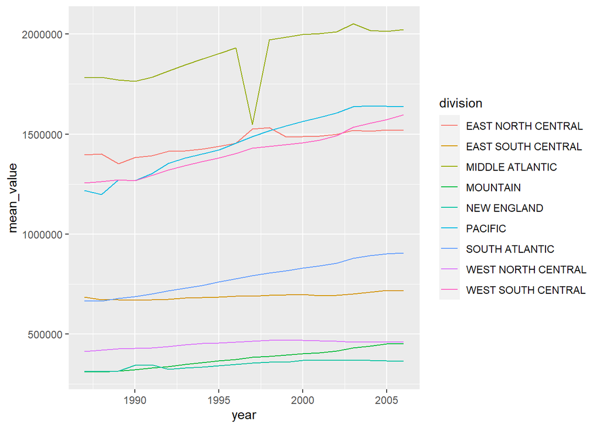

```r
## Run data processing function on the two enrollment URLs
resulta <- wrap_up("https://www4.stat.ncsu.edu/~online/datasets/EDU01a.csv")
resultb <- wrap_up("https://www4.stat.ncsu.edu/~online/datasets/EDU01b.csv")


## Combine these data frames into one object
result <- combine_tibbles(resulta, resultb)

## Plot state data frame
plot(result$non_county)
```

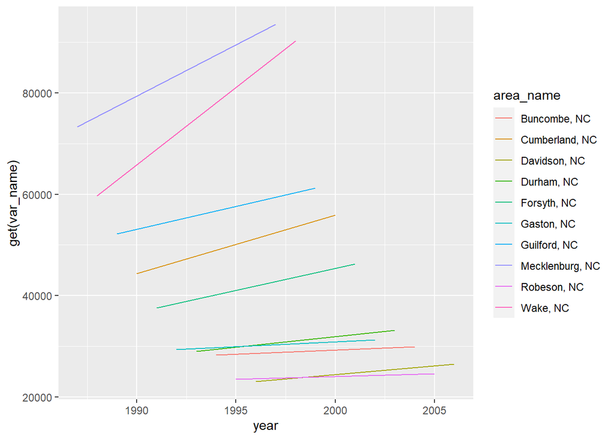

```r
## Plot county data frame
## Specifying the state to be “NC”, the group being the top, the number looked at being 10
plot(result$county, pickstate = "NC", order = "top", number = 10)
```

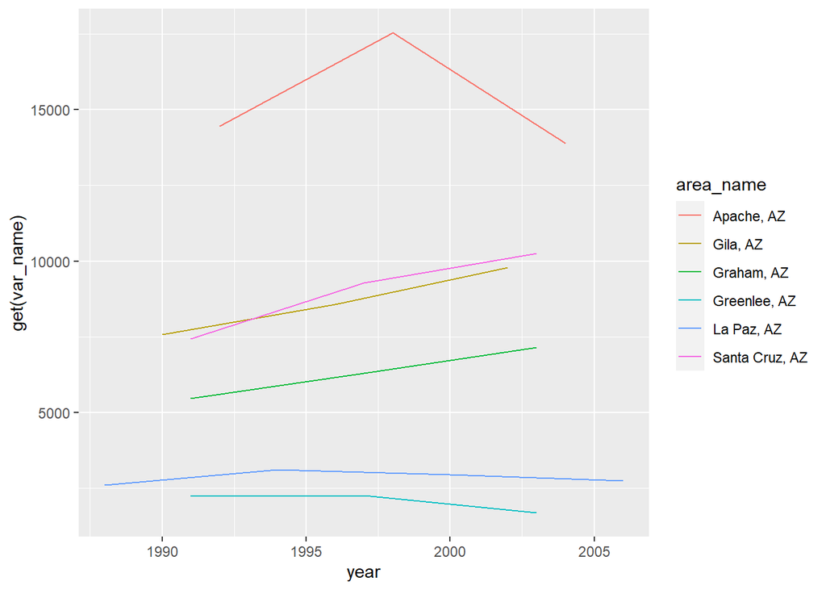

```r
## Specifying the state to be “AZ”, the group being the bottom, the number looked at being 6
plot(result$county, pickstate = "AZ", order = "bottom", number = 6)
```

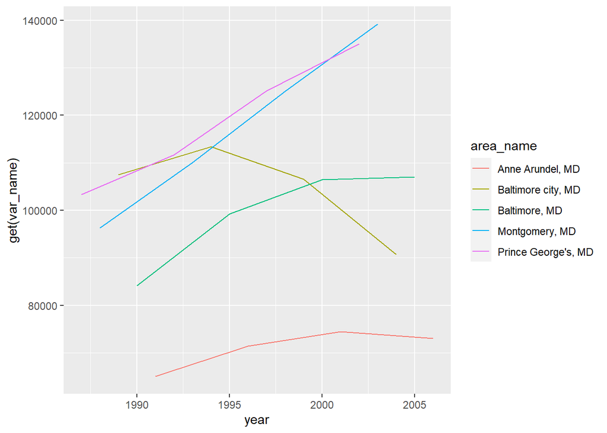

```r
## Without specifying anything (defaults used)
plot(result$county)
```

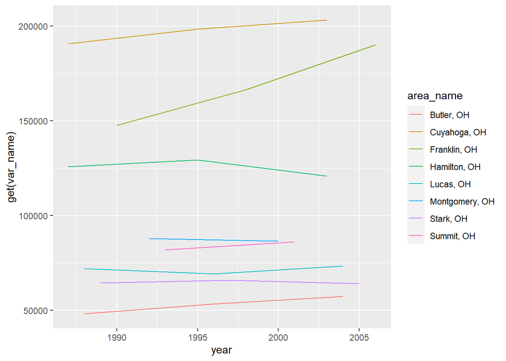

```r
## Specifying the state to be “OH”, the group being the top, the number looked at being 8
plot(result$county, pickstate = "OH", order = "top", number = 8)
```

## Second section

Read in another couple similar data sets and apply functions:

- Run `wrap_up` function on the four data sets at URLs given below:
  - [csv1](https://www4.stat.ncsu.edu/~online/datasets/PST01a.csv)
  - [csv2](https://www4.stat.ncsu.edu/~online/datasets/PST01b.csv)
  - [csv3](https://www4.stat.ncsu.edu/~online/datasets/PST01c.csv)
  - [csv4](https://www4.stat.ncsu.edu/~online/datasets/PST01d.csv)
- Run `combine_tibbles` function three times to put these into one list named as “result” with two data frames as its elements.
- Use the plot.state function on the state data frame
- Use the plot.county function on the county data frame
  - Once specifying the state to be “PA”, the group being the top, the number looked at being 5
  - Once specifying the state to be “TX”, the group being the bottom, the number looked at being 12
  - Once without specifying anything (defaults used)
  - Once specifying the state to be “NY”, the group being the top, the number looked at being 6

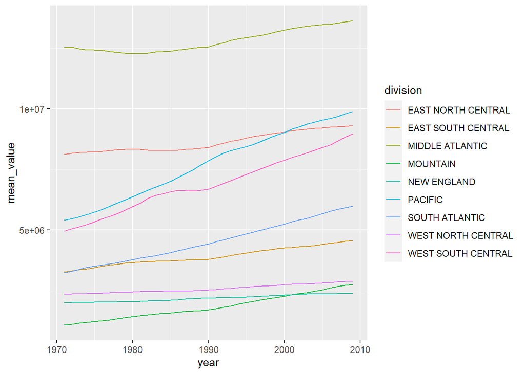

```r
## Run data processing function on the enrollment URLs
resulta <- wrap_up("https://www4.stat.ncsu.edu/~online/datasets/PST01a.csv")
resultb <- wrap_up("https://www4.stat.ncsu.edu/~online/datasets/PST01b.csv")
resultc <- wrap_up("https://www4.stat.ncsu.edu/~online/datasets/PST01c.csv")
resultd <- wrap_up("https://www4.stat.ncsu.edu/~online/datasets/PST01d.csv")


## Combine these dataframes into one object
result <- combine_tibbles(combine_tibbles(combine_tibbles(resulta, resultb), resultc), resultd)


## Plot state data frame
plot(result$non_county)
```

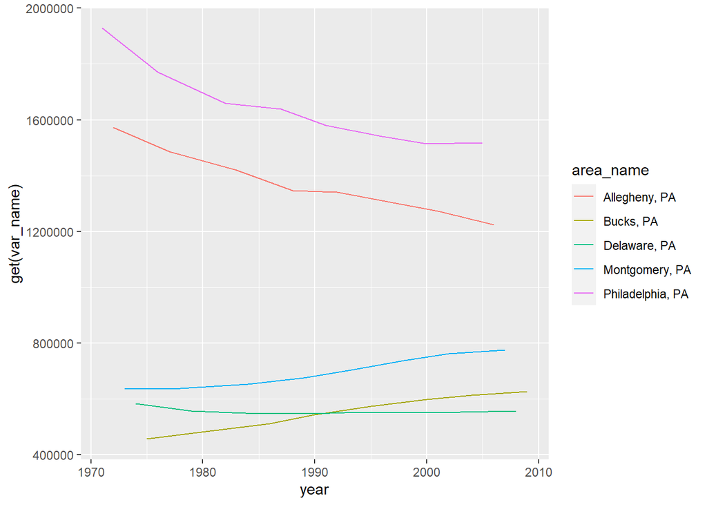

```r
## Plot county data frame
## Specifying the state to be “PA”, the group being the top, the number looked at being 5
plot(result$county, pickstate = "PA", order = "top", number = 5)
```

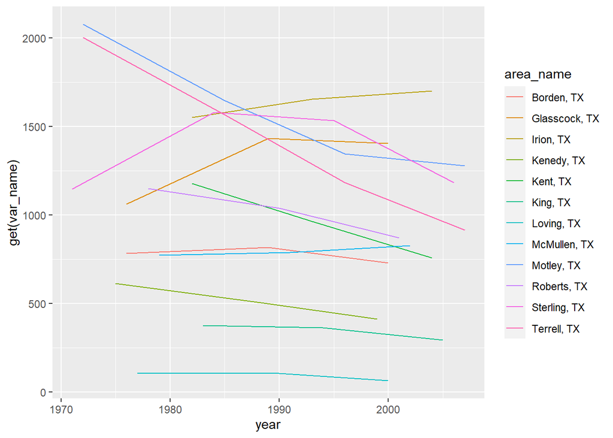

```r
## Specifying the state to be “TX”, the group being the bottom, the number looked at being 12
plot(result$county, pickstate = "TX", order = "bottom", number = 12)
```

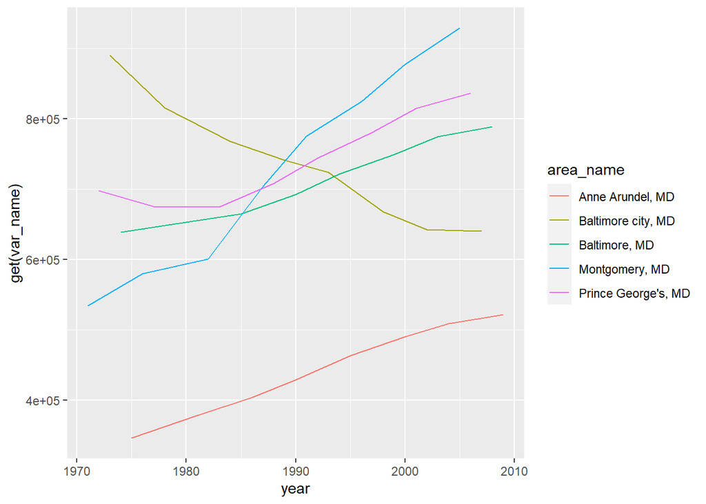

```r
## Without specifying anything (defaults used)
plot(result$county)
```

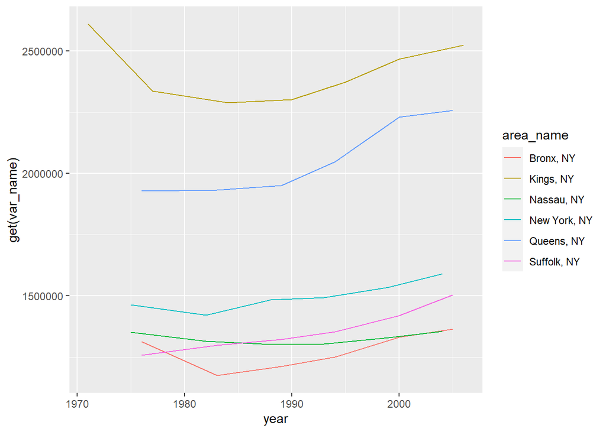

```r
## Specifying the state to be “NY”, the group being the top, the number looked at being 6
plot(result$county, pickstate = "NY", order = "top", number = 6)
```